# Proximity of Philadelphia Schools and Food Sources to Examine Childhood Obesity Risk

BMIN5030 Final Project

Author

Emily Kim

## 1 Github

https://github.com/emikim/BMIN-5030-Final-Project

## 2 Overview

This project explores the relationship between Philadelphia school locations and their surrounding food environments to better understand disparities in access to healthy versus unhealthy food sources and how that might relate to childhood obesity. The goal is determine whether schools across Philadelphia are surrounded by more fast food outlets other healthier food options and to examine how this proximity might relate to childhood obesity.

For this project, I am using a couple of publicly available data sets from OpenDataPhilly. These data sets include spatial data on food retailer locations and categories across Philadelphia, which I will integrate with school location data to assess patterns of healthy and unhealthy food access.

For my project, I met with Anita Stief, MPH, RD, LDN, Education Coordinator for the Penn MPH Program, who provided insights into nutrition disparities and food insecurity in Philadelphia. She emphasized that neighborhoods like West and North Philadelphia face limited access to fresh healthy foods and higher rates of diet related diseases compared to areas like Center City. I also met with Jennifer Orr, MSPHS, Project Manager, in MEHP at Penn, who shared her perspective on how socioeconomic factors and school environments influence children’s dietary habits and long term health. From these discussions, I learned how nutrition, environment, and policy intersect to shape health inequities across Philadelphia communities.

## 3 Introduction

Limited access to healthy foods is a long standing public health challenge that contributes to widening health disparities across cities in the United States. In Philadelphia, where you live in the city matters in terms of your health outcomes. Generally, if people live closer to Center City, their health outcomes and factors are better than those who are farther from Center City. Additionally, the distribution of food retailers is highly uneven with many neighborhood lacking fresh produce, but have many outlets to fast food chains and corner stores. These food environments are closely linked to diet quality, body mass index (BMI), and long term disease risk. Children are especially vulnerable because their daily food choices are shaped around their homes and particularly schools, as that is where they spend most of their time. As a result, school proximity to unhealthy food sources can influence students eating behaviors and contribute to childhood obesity, poor nutrition, and chronic diseases later in life. For this project, I was curious about how where you lived in Philadelphia determines your health outcomes, particulary for children and how this relates to food store locations and if this impacts childhood obesity risk. This project addresses the problem by examining whether Philadelphia schools are surrounded more by fast food and corner stores than by healthy food options, and by considering what the pattern might imply for nutrition equity and community health.

Understanding the issue requires approaches that integrate insights from public health, nutrition science, urban planning, and data science. The people I met with explained that access to healthy food in Philadelphia depends on neighborhood geography to an extent and central areas such as Center City have better access to healthier foods and higher life expediencies, whereas the farther neighborhoods are from Center City are more likely to face food insecurity and higher rates of chronic disease. They also stated how socioeconomic disparities and school level factors shape children’s dietary choices. Their perspectives highlight how environment, policy, and behavior intersect, reinforcing the need to analyze Philadelphia’s school food landscape using spatial data and informatics methods to inform equity nutrition policies and intervention design.

Research Questions:

1. Does proximity to unhealthy food sources differ by geographic region of Philadelphia? Do schools in areas with higher poverty or worse health outcomes have fewer healthy food retailers?
2. Do disparities in food access align with neighborhood poverty?
3. What is the relationship between school proximity to food resources and childhood obesity in Philadelphia?

## 4 Methods

**Data Sources and Design**

I looked at these data sets from OpenDataPhilly:

1. Schools (https://opendataphilly.org/datasets/schools/)
2. Neighborhood Food Retail (https://opendataphilly.org/datasets/neighborhood-food-retail/)
3. Farmers Markets (https://opendataphilly.org/datasets/farmers-markets-locations/)
4. WIC Offices (https://opendataphilly.org/datasets/women-infants-children-wic-offices/)
5. Health of the City (https://opendataphilly.org/datasets/health-of-the-city/)
6. Walkable Access: https://opendataphilly.org/datasets/archived-philadelphia-food-access/
7. Low/No Access: https://opendataphilly.org/datasets/archived-philadelphia-food-access/
8. National Childhood Obesity: https://catalog.data.gov/dataset/?tags=obesity

I couldn’t find any data sets for childhood obesity in Philadelphia specifically, but I think I can draw very strong conclusions with I am working with.

**Packages Used**

**Libraries**

```r
# Load librbaries
library(tidyverse)
library(sf)
library(ggplot2)
library(RColorBrewer)
library(leaflet)
library(classInt)
library(viridis)
```

**Read Data**

```r
# Spatial layers
schools      <- st_read("data/schools.geojson")
food_retail  <- st_read("data/neighfoodretail.geojson")
farmers      <- st_read("data/farmers.geojson")
wic          <- st_read("data/wic.geojson")
bev_tax      <- st_read("data/beverages.geojson")
```

```
replacing null geometries with empty geometries
Simple feature collection with 922 features and 9 fields (with 922 geometries empty)
Geometry type: GEOMETRYCOLLECTION
Dimension:     XY
Bounding box:  xmin: NA ymin: NA xmax: NA ymax: NA
Geodetic CRS:  WGS 84
```

```r
walk_access  <- st_read("data/walk_access.geojson")
low_no       <- st_read("data/low_no.geojson")
# Health of the City
health_city  <- read_csv("data/cityhealth.csv")
# Childhood Obesity
child_obesity <- read.csv("data/child_obesity.csv")
```

**Create CRS**

```r
target_crs <- 2272   # Pennsylvania South StatePlane / Feet

schools       <- st_transform(schools,       target_crs)
food_retail   <- st_transform(food_retail,   target_crs)
walk_access   <- st_transform(walk_access,   target_crs)
low_no        <- st_transform(low_no,        target_crs)
farmers       <- st_transform(farmers,       target_crs)
wic           <- st_transform(wic,           target_crs)
```

**Preview Datasets**

```r
summary(schools)
```

```
      aun              school_num   location_id        school_name
 Min.   :100510000   Min.   :3445   Length:495         Length:495
 1st Qu.:126515001   1st Qu.:3752   Class :character   Class :character
 Median :126515001   Median :6527   Mode  :character   Mode  :character
 Mean   :163032553   Mean   :5776
 3rd Qu.:226511157   3rd Qu.:7664
 Max.   :326517786   Max.   :8493
 NA's   :51          NA's   :208
 school_name_label  street_address       zip_code         phone_number
 Length:495         Length:495         Length:495         Length:495
 Class :character   Class :character   Class :character   Class :character
 Mode  :character   Mode  :character   Mode  :character   Mode  :character




 grade_level         grade_org           enrollment          type
 Length:495         Length:495         Min.   :   1.0   Min.   :1.000
 Class :character   Class :character   1st Qu.: 270.0   1st Qu.:1.000
 Mode  :character   Mode  :character   Median : 446.0   Median :1.000
                                       Mean   : 548.5   Mean   :1.768
                                       3rd Qu.: 656.0   3rd Qu.:3.000
                                       Max.   :3467.0   Max.   :3.000
                                       NA's   :162
 type_specific         objectid              geometry
 Length:495         Min.   :  1.0   POINT        :495
 Class :character   1st Qu.:124.5   epsg:2272    :  0
 Mode  :character   Median :248.0   +proj=lcc ...:  0
                    Mean   :248.0
                    3rd Qu.:371.5
                    Max.   :495.0
```

```r
summary(food_retail)
```

```
    OBJECTID        GEOID10          NON_RESIDENTIAL      TOTAL_LPSS
 Min.   :   1.0   Length:1336        Length:1336        Min.   :  0.00
 1st Qu.: 334.8   Class :character   Class :character   1st Qu.: 16.00
 Median : 668.5   Mode  :character   Mode  :character   Median : 27.00
 Mean   : 668.5                                         Mean   : 29.66
 3rd Qu.:1002.2                                         3rd Qu.: 39.00
 Max.   :1336.0                                         Max.   :148.00
                                                        NA's   :11
  LPSS_PER1000      TOTAL_HPSS      HPSS_PER1000       PCT_HPSS
 Min.   :  0.00   Min.   : 0.000   Min.   : 0.000   Min.   : 0.000
 1st Qu.: 13.05   1st Qu.: 1.250   1st Qu.: 1.239   1st Qu.: 5.556
 Median : 24.47   Median : 2.750   Median : 2.558   Median : 9.677
 Mean   : 31.09   Mean   : 3.788   Mean   : 3.817   Mean   :11.820
 3rd Qu.: 41.79   3rd Qu.: 4.250   3rd Qu.: 4.507   3rd Qu.:15.789
 Max.   :224.62   Max.   :32.000   Max.   :62.992   Max.   :80.952
 NA's   :11       NA's   :11       NA's   :11       NA's   :11
 HPSS_ACCESS        SUPERMARKET_ACCESS PCT_VEHICLE_AVAILABILITY
 Length:1336        Length:1336        Min.   :  0.00
 Class :character   Class :character   1st Qu.: 53.73
 Mode  :character   Mode  :character   Median : 69.92
                                       Mean   : 68.05
                                       3rd Qu.: 84.39
                                       Max.   :100.00
                                       NA's   :10
 TOTAL_RESTAURANTS  PCT_POVERTY    HIGH_POVERTY        Shape__Area
 Min.   :  0.000   Min.   : 0.00   Length:1336        Min.   :   28545
 1st Qu.:  1.000   1st Qu.:11.04   Class :character   1st Qu.:  139205
 Median :  2.000   Median :22.91   Mode  :character   Median :  212464
 Mean   :  4.823   Mean   :26.52                      Mean   :  471194
 3rd Qu.:  5.000   3rd Qu.:39.30                      3rd Qu.:  388725
 Max.   :174.000   Max.   :92.45                      Max.   :34978502
                   NA's   :9
 Shape__Length              geometry
 Min.   :  714.4   POLYGON      :1336
 1st Qu.: 1621.2   epsg:2272    :   0
 Median : 2081.4   +proj=lcc ...:   0
 Mean   : 2735.2
 3rd Qu.: 3001.0
 Max.   :40155.3
```

```r
summary(farmers)
```

```
    objectid        editdate                       name
 Min.   :10.00   Min.   :2024-05-15 16:14:41   Length:32
 1st Qu.:35.50   1st Qu.:2025-02-01 13:58:56   Class :character
 Median :64.50   Median :2025-06-10 16:44:01   Mode  :character
 Mean   :57.03   Mean   :2025-03-19 00:57:19
 3rd Qu.:77.25   3rd Qu.:2025-07-10 20:43:45
 Max.   :87.00   Max.   :2025-10-30 09:27:24

   operator           address              zip            transit_parking
 Length:32          Length:32          Length:32          Length:32
 Class :character   Class :character   Class :character   Class :character
 Mode  :character   Mode  :character   Mode  :character   Mode  :character




 transit_bus        transit_subway     transit_regional_rail contact_website
 Length:32          Length:32          Length:32             Length:32
 Class :character   Class :character   Class :character      Class :character
 Mode  :character   Mode  :character   Mode  :character      Mode  :character




 contact_phone      contact_email      contact_facebook   contact_instagram
 Length:32          Length:32          Length:32          Length:32
 Class :character   Class :character   Class :character   Class :character
 Mode  :character   Mode  :character   Mode  :character   Mode  :character




 contact_twitter    hours_mon_start    hours_mon_end      hours_mon_exceptions
 Length:32          Length:32          Length:32          Length:32
 Class :character   Class :character   Class :character   Class :character
 Mode  :character   Mode  :character   Mode  :character   Mode  :character




```

[output cut: 61 more lines]

```
                                                            3rd Qu.:11.25
                                                            Max.   :28.00
                                                            NA's   :20
 season_closing_month season_closing_day payment_cash
 Length:32            Min.   : 1.00      Length:32
 Class :character     1st Qu.: 7.50      Class :character
 Mode  :character     Median :21.00      Mode  :character
                      Mean   :17.50
                      3rd Qu.:26.25
                      Max.   :30.00
                      NA's   :20
 payment_other_low_cost payment_low_cost            geometry
 Length:32              Length:32          POINT        :32
 Class :character       Class :character   epsg:2272    : 0
 Mode  :character       Mode  :character   +proj=lcc ...: 0
```

```r
summary(wic)
```

```
    objectid       loc_name            status              score
 Min.   : 1.00   Length:10          Length:10          Min.   : 89.04
 1st Qu.: 3.25   Class :character   Class :character   1st Qu.:100.00
 Median : 5.50   Mode  :character   Mode  :character   Median :100.00
 Mean   : 5.50                                         Mean   : 98.90
 3rd Qu.: 7.75                                         3rd Qu.:100.00
 Max.   :10.00                                         Max.   :100.00
  match_type         match_addr            side             user_fld
 Length:10          Length:10          Length:10          Length:10
 Class :character   Class :character   Class :character   Class :character
 Mode  :character   Mode  :character   Mode  :character   Mode  :character



  addr_type          arc_street          arc_zip              name
 Length:10          Length:10          Length:10          Length:10
 Class :character   Class :character   Class :character   Class :character
 Mode  :character   Mode  :character   Mode  :character   Mode  :character



   address           address_2              zip        phone_number
 Length:10          Length:10          Min.   :19131   Length:10
 Class :character   Class :character   1st Qu.:19133   Class :character
 Mode  :character   Mode  :character   Median :19138   Mode  :character
                                       Mean   :19139
                                       3rd Qu.:19144
                                       Max.   :19152
          geometry
 POINT        :10
 epsg:2272    : 0
 +proj=lcc ...: 0
```

```r
summary(bev_tax)
```

```
 registration_type  doing_business_as_name street_address
 Length:922         Length:922             Length:922
 Class :character   Class :character       Class :character
 Mode  :character   Mode  :character       Mode  :character
     city              state             zip_code         phone_number
 Length:922         Length:922         Length:922         Length:922
 Class :character   Class :character   Class :character   Class :character
 Mode  :character   Mode  :character   Mode  :character   Mode  :character
 phone_extension      website                        geometry
 Length:922         Length:922         GEOMETRYCOLLECTION:922
 Class :character   Class :character   epsg:4326         :  0
 Mode  :character   Mode  :character   +proj=long...     :  0
```

```r
summary(walk_access)
```

```
    OBJECTID        GEOID             ACCESS_           Shape__Area
 Min.   :    1   Length:18872       Length:18872       Min.   :      50
 1st Qu.: 4719   Class :character   Class :character   1st Qu.:   64297
 Median : 9436   Mode  :character   Mode  :character   Median :  103723
 Mean   : 9436                                         Mean   :  210413
 3rd Qu.:14154                                         3rd Qu.:  166753
 Max.   :18872                                         Max.   :37522648
 Shape__Length              geometry
 Min.   :   32.3   MULTIPOLYGON :18872
 1st Qu.: 1182.9   epsg:2272    :    0
 Median : 1474.2   +proj=lcc ...:    0
 Mean   : 1857.3
 3rd Qu.: 1872.9
 Max.   :36758.0
```

```r
summary(low_no)
```

```
    OBJECTID       GEOID             ACCESS_           Shape__Area
 Min.   :   1   Length:4016        Length:4016        Min.   :     303
 1st Qu.:1005   Class :character   Class :character   1st Qu.:   66136
 Median :2008   Mode  :character   Mode  :character   Median :   97353
 Mean   :2008                                         Mean   :  159175
 3rd Qu.:3012                                         3rd Qu.:  143032
 Max.   :4016                                         Max.   :11247744
 Shape__Length              geometry
 Min.   :  124.4   MULTIPOLYGON :4016
 1st Qu.: 1183.0   epsg:2272    :   0
 Median : 1419.9   +proj=lcc ...:   0
 Mean   : 1639.0
 3rd Qu.: 1686.4
 Max.   :18467.0
```

**Clean Data**

Merged data sets, recoding variables, and filtering.

```r
# Libraries
library(tidyverse)
library(sf)

# Set a common CRS (Pennsylvania South Stateplane, EPSG:2272)
target_crs <- 2272

schools     <- st_transform(schools,     crs = target_crs)
food_retail <- st_transform(food_retail, crs = target_crs)
walk_access <- st_transform(walk_access, crs = target_crs)
low_no      <- st_transform(low_no,      crs = target_crs)
farmers     <- st_transform(farmers,     crs = target_crs)
wic         <- st_transform(wic,         crs = target_crs)

# Clean SCHOOLS
schools_clean_sf <- schools %>%
  transmute(
    school_id   = location_id,
    school_name = school_name,
    address     = street_address,
    zip         = as.character(zip_code),
    type        = type,
    grade_org   = grade_org,
    enrollment  = enrollment,
    school_level = case_when(
      str_detect(grade_org, regex("Elementary", ignore_case = TRUE)) ~ "Elementary",
      str_detect(grade_org, regex("Middle",     ignore_case = TRUE)) ~ "Middle",
      str_detect(grade_org, regex("High",       ignore_case = TRUE)) ~ "High",
      TRUE ~ "Other"
    )
  )

# Clean FOOD RETAIL (HPSS, LPSS, poverty)
food_retail_clean_sf <- food_retail %>%
  transmute(
    GEOID10,
    area_healthy   = TOTAL_HPSS,
    area_unhealthy = TOTAL_LPSS,
    area_total     = TOTAL_HPSS + TOTAL_LPSS,
    healthy_ratio  = if_else(
      TOTAL_HPSS + TOTAL_LPSS > 0,
      TOTAL_HPSS / (TOTAL_HPSS + TOTAL_LPSS),
      NA_real_
    ),
    pct_poverty       = PCT_POVERTY,
    high_poverty_raw  = HIGH_POVERTY,
    pct_vehicle_avail = PCT_VEHICLE_AVAILABILITY,
    geometry
  )

# Clean WALK ACCESS + LOW/NO ACCESS
walk_access_clean_sf <- walk_access %>%
  transmute(
    GEOID = GEOID,
    walk_access_status = ACCESS_,
    geometry
  ) %>%
  st_make_valid()

low_no_clean_sf <- low_no %>%
  transmute(
    GEOID = GEOID,
    low_no_access_status = ACCESS_,
    geometry
  ) %>%
  st_make_valid()

# Real HEALTHY POINTS: Farmers + WIC
farmers_fixed_sf <- farmers %>%
  mutate(zip = as.character(zip))

wic_fixed_sf <- wic %>%
  mutate(zip = as.character(zip))

healthy_all_points <- bind_rows(
  farmers_fixed_sf %>% mutate(type = "Farmers"),
  wic_fixed_sf      %>% mutate(type = "WIC")
) %>%
  select(type, geometry)

# Spatial joins: attach neighborhood context to SCHOOLS

# Schools + food retail (HPSS / LPSS / poverty)
schools_with_retail <- schools_clean_sf %>%
  st_join(food_retail_clean_sf, join = st_within)

# Add walk access
schools_with_walk <- schools_with_retail %>%
  st_join(walk_access_clean_sf, join = st_within)

# Add low/no access
schools_with_access <- schools_with_walk %>%
  st_join(low_no_clean_sf, join = st_within)

# Count nearby healthy points within ~10-min walk (~800 ft)
school_buffers_10 <- schools_with_access %>%
  st_buffer(dist = 800)   # ~10-minute walk

healthy_counts_10 <- school_buffers_10 %>%
  st_join(healthy_all_points, join = st_intersects) %>%
  st_drop_geometry() %>%
  group_by(school_id) %>%
  summarize(
    n_healthy_10 = n(),
    .groups = "drop"
  )

# Final MERGED DATA
merged_data <- schools_with_access %>%
  st_drop_geometry() %>%
  left_join(healthy_counts_10, by = "school_id") %>%
  mutate(
    high_poverty = case_when(
      high_poverty_raw %in% c(1, "1", "Yes", "YES", "yes") ~ 1,
      high_poverty_raw %in% c(0, "0", "No",  "NO",  "no")  ~ 0,
      TRUE ~ NA_real_
    ),
    has_healthy_10 = case_when(
      is.na(n_healthy_10) ~ NA_real_,
      n_healthy_10 == 0   ~ 0,
      n_healthy_10 > 0    ~ 1
    )
  ) %>%
  select(
    school_id,
    school_name,
    address,
    zip,
    type,
    school_level,
    enrollment,
    area_healthy,
    area_unhealthy,
    area_total,
    healthy_ratio,
    pct_poverty,
    high_poverty,
    pct_vehicle_avail,
    walk_access_status,
    low_no_access_status,
    n_healthy_10,
    has_healthy_10
  )

# Quick check
table(merged_data$school_level, useNA = "ifany")
```

```
Other
  495
```

```r
summary(merged_data)
```

```
  school_id         school_name          address              zip
 Length:495         Length:495         Length:495         Length:495
 Class :character   Class :character   Class :character   Class :character
 Mode  :character   Mode  :character   Mode  :character   Mode  :character




      type       school_level         enrollment      area_healthy
 Min.   :1.000   Length:495         Min.   :   1.0   Min.   : 0.000
 1st Qu.:1.000   Class :character   1st Qu.: 270.0   1st Qu.: 2.000
 Median :1.000   Mode  :character   Median : 446.0   Median : 3.000
 Mean   :1.768                      Mean   : 548.5   Mean   : 4.587
 3rd Qu.:3.000                      3rd Qu.: 656.0   3rd Qu.: 5.500
 Max.   :3.000                      Max.   :3467.0   Max.   :31.250
                                    NA's   :162      NA's   :3
 area_unhealthy     area_total     healthy_ratio      pct_poverty
 Min.   :  1.00   Min.   :  1.00   Min.   :0.00000   Min.   : 0.00
 1st Qu.: 18.00   1st Qu.: 19.88   1st Qu.:0.05882   1st Qu.:10.85
 Median : 31.00   Median : 34.50   Median :0.10391   Median :25.21
 Mean   : 35.59   Mean   : 40.17   Mean   :0.12261   Mean   :27.85
 3rd Qu.: 45.00   3rd Qu.: 50.06   3rd Qu.:0.15493   3rd Qu.:41.90
 Max.   :148.00   Max.   :171.75   Max.   :0.76471   Max.   :92.45
 NA's   :3        NA's   :3        NA's   :3         NA's   :1
  high_poverty    pct_vehicle_avail walk_access_status low_no_access_status
 Min.   :0.0000   Min.   :  7.258   Length:495         Length:495
 1st Qu.:0.0000   1st Qu.: 52.326   Class :character   Class :character
 Median :1.0000   Median : 68.649   Mode  :character   Mode  :character
 Mean   :0.5891   Mean   : 67.859
 3rd Qu.:1.0000   3rd Qu.: 84.502
 Max.   :1.0000   Max.   :100.000
 NA's   :1        NA's   :2
  n_healthy_10    has_healthy_10
 Min.   :  1.00   Min.   :1
 1st Qu.:  1.00   1st Qu.:1
 Median :  1.00   Median :1
 Mean   : 56.37   Mean   :1
 3rd Qu.:166.00   3rd Qu.:1
 Max.   :166.00   Max.   :1
```

```r
head(merged_data)
```

```
  school_id                    school_name                address   zip type
1      <NA> ST MARYS INTERPAROCHIAL SCHOOL          440 LOCUST ST 19106    3
2      <NA>               ST MARTHA SCHOOL       11321 ACADEMY RD 19154    3
3      <NA>           MATERNITY BVM SCHOOL 9322 OLD BUSTLETON AVE 19115    3
4      <NA>     OUR LADY OF CALVARY SCHOOL       11023 KIPLING LN 19154    3
5      <NA>         CHRIST THE KING SCHOOL   3205 CHESTERFIELD RD 19114    3
6      <NA>     BEGINNINGS LEARNING CENTER          620 S 10TH ST 19147    3
  school_level enrollment area_healthy area_unhealthy area_total healthy_ratio
1        Other         NA         6.25             37      43.25     0.1445087
2        Other         NA         1.00              4       5.00     0.2000000
3        Other         NA         1.00             19      20.00     0.0500000
4        Other         NA         0.00              2       2.00     0.0000000
5        Other         NA         2.00              7       9.00     0.2222222
6        Other         NA        31.25             65      96.25     0.3246753
  pct_poverty high_poverty pct_vehicle_avail walk_access_status
1  13.9137510            0          64.08346        High Access
2   4.4354839            0          89.36170         Low Access
3  22.1572795            1          84.23077         Low Access
4   0.5568815            0          92.01681          No Access
5  11.0479285            0          91.10048         Low Access
6  16.8763103            0          63.20658        High Access
  low_no_access_status n_healthy_10 has_healthy_10
1                 <NA>          166              1
2                 <NA>          166              1
3                 <NA>          166              1
4                 <NA>          166              1
5                 <NA>          166              1
6                 <NA>          166              1
```

area_healthy = number of high produce stores (HPSS)  
area_unhealthy = number of low produce / corner type stores (LPSS)  
area_total = HPSS + LPSS  
healthy ratio = HPSS / (HPSS+LPSS)\

Food retail data were simplified into analysis-ready indicators: counts of healthy stores (HPSS), unhealthy stores (LPSS), total stores, and a healthy food ratio (HPSS ÷ [HPSS + LPSS]). Neighborhood context variables—including poverty percentage, high-poverty status, and vehicle availability—were retained.

Walk-access and low/no-access datasets were validated and spatially joined to each school. Farmers markets and WIC offices were combined into a single layer of healthy-food locations. For each school, an 800-foot buffer (approx. 10-minute walk) was used to count nearby healthy food points.

All layers were merged through sequential spatial joins, producing one comprehensive dataset per school containing neighborhood poverty, food retailer mix, healthy food ratio, walk-access status, and counts of healthy food sources. This final cleaned dataset was used for mapping, descriptive statistics, clustering, and regression analyses.

## 5 Results

**Distribution of Schools**

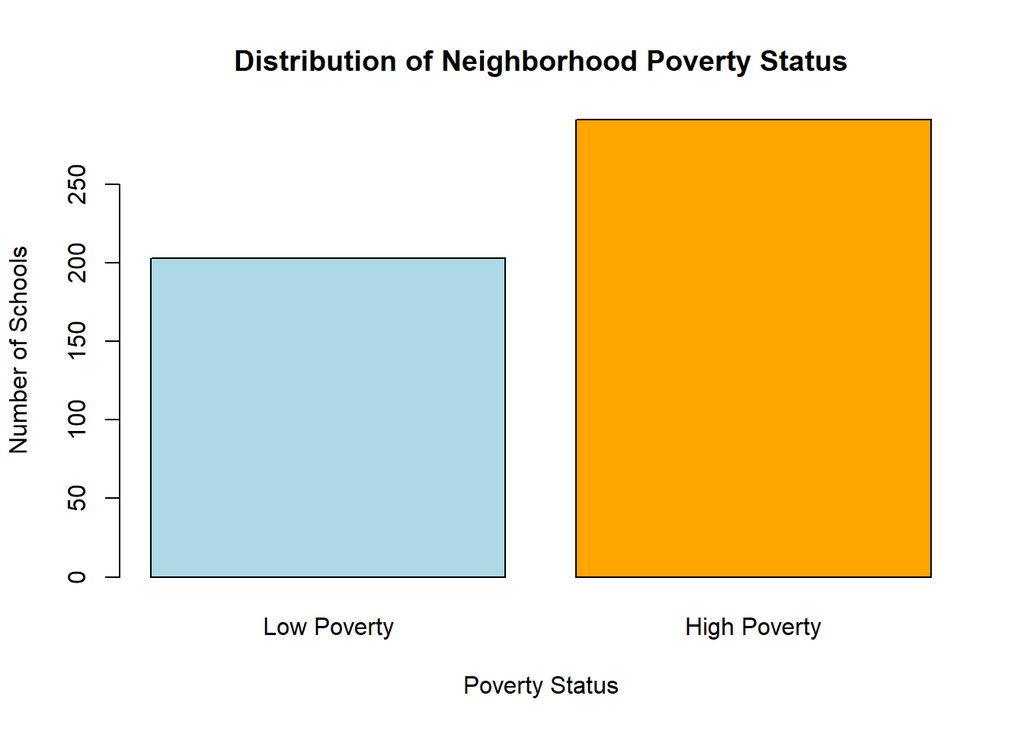

```r
barplot(
  table(merged_data$high_poverty),
  main = "Distribution of Neighborhood Poverty Status",
  xlab = "Poverty Status",
  ylab = "Number of Schools",
  col = c("lightblue", "orange"),
  names.arg = c("Low Poverty", "High Poverty")
)
```

First I wanted to see the distribution of schools. The barplot shows that more schools in Philadelphia are located in high poverty neighborhoods than in low poverty neighborhoods since the bar is noticeably taller. This could also indicate that a substantial portion fo schools are situated in areas with higher socioeconomic disadvantage. This suggests that many students attend schools in communities facing greater structural barriers such as reduced resources, limited access to healthy food retailers, and higher levels of food insecurity. This is important because schools in high poverty neighborhoods are more likely to be surrounded by unhealthy options and fewer healthier options, amplifying disparities in long term health outcomes.

**Food Sources Around Schools**

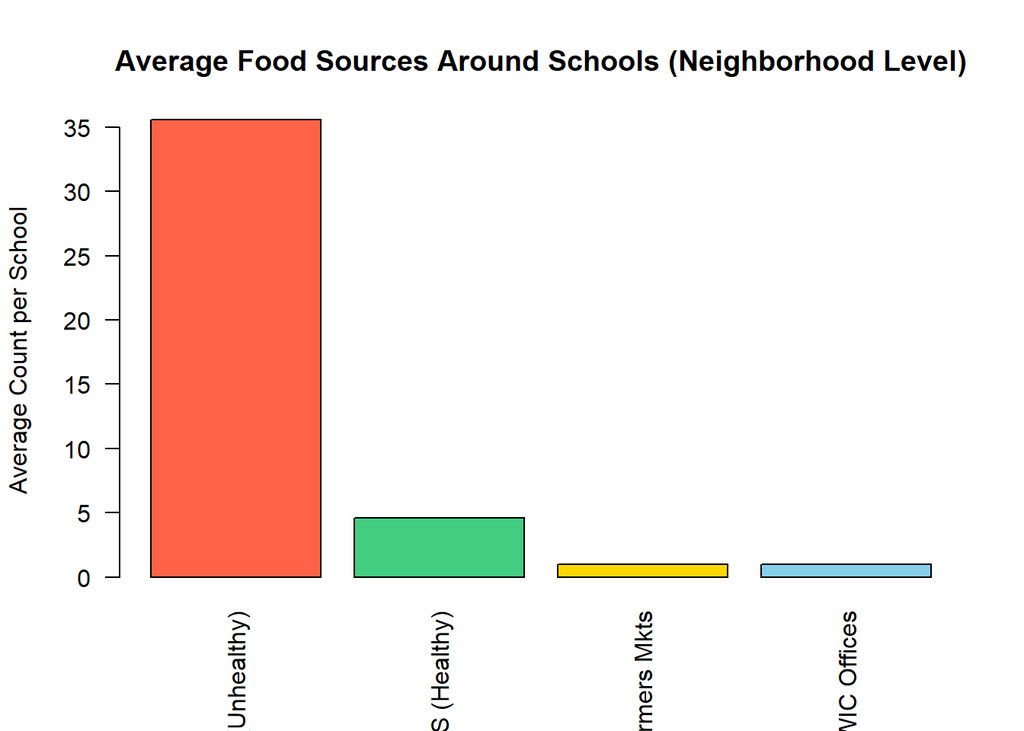

```r
schools_with_tract <- st_join(
  schools_clean_sf,
  food_retail_clean_sf,
  join = st_intersects
)

farmers_per_tract <- st_join(food_retail_clean_sf, farmers_fixed_sf) %>%
  st_drop_geometry() %>%
  group_by(GEOID10) %>%
  summarize(n_farmers = n(), .groups = "drop")

wic_per_tract <- st_join(food_retail_clean_sf, wic_fixed_sf) %>%
  st_drop_geometry() %>%
  group_by(GEOID10) %>%
  summarize(n_wic = n(), .groups = "drop")
schools_env <- schools_with_tract %>%
  st_drop_geometry() %>%
  left_join(farmers_per_tract, by = "GEOID10") %>%
  left_join(wic_per_tract, by = "GEOID10") %>%
  mutate(
    n_farmers = replace_na(n_farmers, 0),
    n_wic     = replace_na(n_wic, 0)
  )

avg_LPSS  <- mean(schools_env$area_unhealthy, na.rm = TRUE)
avg_HPSS  <- mean(schools_env$area_healthy,  na.rm = TRUE)
avg_farm  <- mean(schools_env$n_farmers,     na.rm = TRUE)
avg_wic   <- mean(schools_env$n_wic,         na.rm = TRUE)


values <- c(avg_LPSS, avg_HPSS, avg_farm, avg_wic)

barplot(
  values,
  names.arg = c("LPSS (Unhealthy)", "HPSS (Healthy)", "Farmers Mkts", "WIC Offices"),
  col = c("tomato", "seagreen3", "gold", "skyblue"),
  main = "Average Food Sources Around Schools (Neighborhood Level)",
  ylab = "Average Count per School",
  las = 2
)
```

For my project, “healthy food sources” are defined as stores that regularly sell fresh produce such as supermarkets, produce markets, some large grocery stores, co-ops, farmers markets, or independent stores with produce - HPSS = High Produce Selling Stores.

“Unhealthy food sources” are defined as stores that do not regularly sell produce such as corner stores, bodegas, mini marts, fast food chains, takeout, and gas stations - LPSS = Low Produce Selling Stores.

**Healthy Food Sources in Philadelphia**

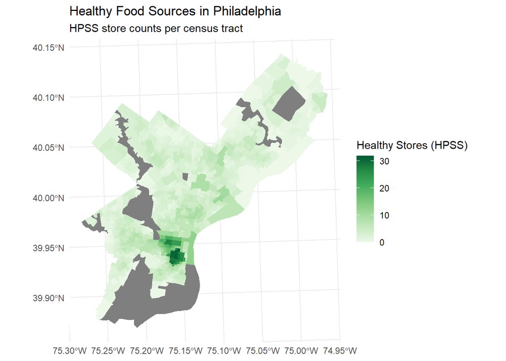

```r
ggplot() +
  geom_sf(
    data = food_retail_clean_sf,
    aes(fill = area_healthy),
    color = NA
  ) +
  scale_fill_distiller(
    palette = "Greens",
    direction = 1,
    name = "Healthy Stores (HPSS)"
  ) +
  labs(
    title = "Healthy Food Sources in Philadelphia",
    subtitle = "HPSS store counts per census tract"
  ) +
  theme_minimal()
```

Then, I wanted to see where healthy food sources were in Philadelphia. Healthy food sources are clustered towards the middle of the city near Center City because the areas are darker, indicating healthier options. And the farther out from Center City, the shade turns lighter, which indicates unhealthier options.

**Proximity of Schools to Healthy and Unhealthy Food Sources**

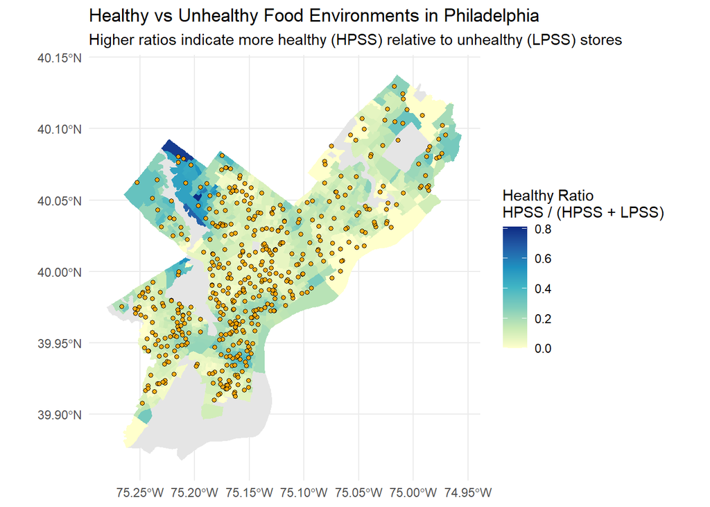

```r
library(sf)
library(ggplot2)
library(dplyr)
library(RColorBrewer)

# Create lat/long versions (EPSG:4326) for plotting
philly_food_ll <- st_transform(food_retail_clean_sf, 4326)
schools_ll     <- st_transform(schools_clean_sf,     4326)

# Plot map
ggplot() +
  # Background: tracts shaded by healthy_ratio
  geom_sf(
    data  = philly_food_ll,
    aes(fill = healthy_ratio),
    color = NA
  ) +
  scale_fill_distiller(
    palette   = "YlGnBu",
    direction = 1,
    name      = "Healthy Ratio\nHPSS / (HPSS + LPSS)",
    na.value  = "grey90"
  ) +
  # Schools: points on top
  geom_sf(
    data  = schools_ll,
    color = "black",
    fill  = "orange",
    shape = 21,
    size  = 1.2,
    alpha = 0.9
  ) +
  labs(
    title    = "Healthy vs Unhealthy Food Environments in Philadelphia",
    subtitle = "Higher ratios indicate more healthy (HPSS) relative to unhealthy (LPSS) stores",
    x = NULL,
    y = NULL
  ) +
  theme_minimal()
```

```r
summary(merged_data$healthy_ratio)
```

```
   Min. 1st Qu.  Median    Mean 3rd Qu.    Max.    NA's
0.00000 0.05882 0.10391 0.12261 0.15493 0.76471       3
```

**Health Outcomes - Life Expectancy**

[figure not shown]

```r
lifeexp_pd <- health_city %>%
  filter(
    geography == "Planning district",
    metric_name == "life_expectancy_at_birth"
  ) %>%
  filter(metric_value > 0 & metric_value < 120) %>%   # remove -99999 and unrealistic values
  mutate(metric_value = as.numeric(metric_value)) %>%
  group_by(geography_name) %>%
  filter(year == max(year, na.rm = TRUE)) %>%
  ungroup() %>%
  select(
    planning_district = geography_name,
    life_expectancy = metric_value
  )

ggplot(lifeexp_pd,
       aes(x = reorder(planning_district, life_expectancy),
           y = life_expectancy)) +
  geom_col(fill = "steelblue") +
  coord_flip() +
  labs(
    title    = "Life Expectancy at Birth by Philadelphia Planning District",
    subtitle = "Higher = better health outcomes; -99999 values removed",
    x        = "Planning District",
    y        = "Life Expectancy (years)"
  ) +
  theme_minimal(base_size = 13)
```

I also wanted to see general life expectancy around Philadelphia. This graph shows you that there are higher life expectations in Central Philadelphia than North Philadelphia. This patter aligns with the previous mapped food environments, where neighborhoods farther from Center City also have fewer healthy food retailers and higher concentrations of unhealthy outlets.

**Health Outcomes - Childhood Obesity**

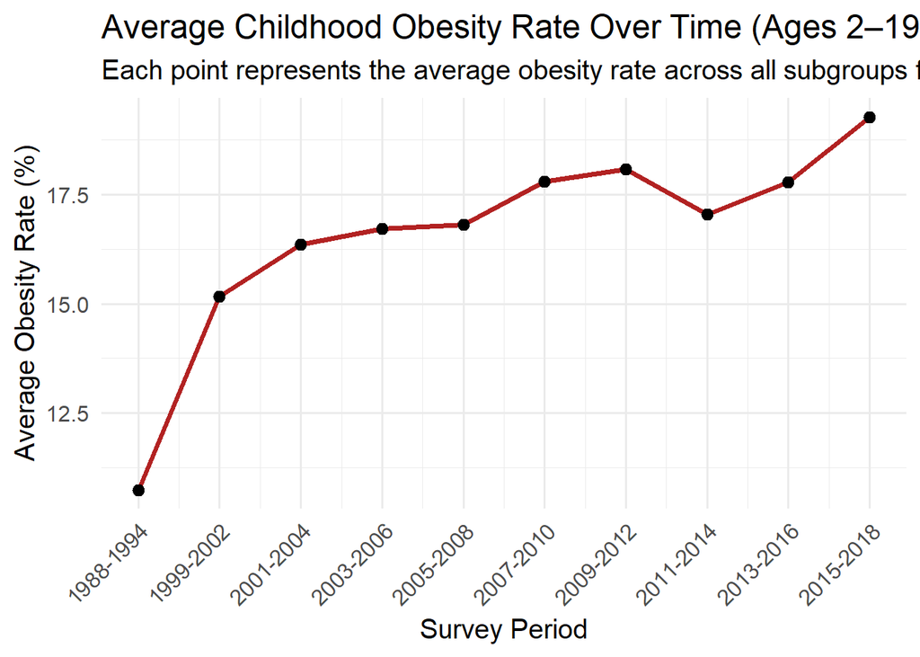

```r
library(tidyverse)

# Load data
child_obesity <- read.csv("data/child_obesity.csv")

# Clean and summarize:
# 1. Convert YEAR_NUM to numeric
# 2. Compute average obesity rate for each time period
obesity_avg <- child_obesity %>%
  mutate(period = YEAR_NUM) %>%
  group_by(period, YEAR) %>%        # keep original YEAR label for plotting
  summarize(mean_obesity = mean(ESTIMATE, na.rm = TRUE), .groups = "drop")

# Plot the cleaned trend
ggplot(obesity_avg, aes(x = period, y = mean_obesity)) +
  geom_line(color = "firebrick", size = 1.3) +
  geom_point(color = "black", size = 2.5) +
  scale_x_continuous(breaks = obesity_avg$period,
                     labels = obesity_avg$YEAR) +
  labs(
    title = "Average Childhood Obesity Rate Over Time (Ages 2–19)",
    subtitle = "Each point represents the average obesity rate across all subgroups for that time period",
    x = "Survey Period",
    y = "Average Obesity Rate (%)"
  ) +
  theme_minimal(base_size = 15) +
  theme(axis.text.x = element_text(angle = 45, hjust = 1))
```

```r
obesity_avg <- child_obesity %>%
  group_by(YEAR) %>%
  summarize(
    obesity_rate = mean(ESTIMATE, na.rm = TRUE)
  )

baseline_obesity <- obesity_avg$obesity_rate[nrow(obesity_avg)]
baseline_obesity
```

```
[1] 19.28228
```

And most importantly, I wanted to see national trends of childhood obesity. This graph shows us in a national context of childhood obesity among U.S kids is high and has risen over time in the past 30 years. I couldn’t find a dataset specifically for childhood obesity in Philadelphia, but I can gather evidence from all the maps to predict childhood obesity rates and schools around food environments. Nationally, childhood obesity affects approximately 19% of children. However, environmental factors around Philadelphia schools vary dramatically and may indicate higher local risk. See the data analysis section next to see how I made conclusions.

**Data Analysis and Quantitative Comparisons:**

**Poverty vs Healthy Food Availability**

```r
merged_data %>%
  group_by(high_poverty) %>%
  summarize(
    mean_healthy_ratio = mean(healthy_ratio, na.rm = TRUE),
    mean_unhealthy     = mean(area_unhealthy, na.rm = TRUE)
  )
```

```
# A tibble: 3 × 3
  high_poverty mean_healthy_ratio mean_unhealthy
         <dbl>              <dbl>          <dbl>
1            0             0.157            28.9
2            1             0.0987           40.2
3           NA           NaN               NaN
```

Here, I am seeing the comparison between of food availability between different poverty levels.

high_poverty = 0 = NOT high poverty neighborhoods  
high_poverty_1 = high poverty neighborhoods  
NA = missing data

Schools in high-poverty Philadelphia neighborhoods had a 40% lower healthy food ratio (9.9% vs. 15.7%) and 40% more unhealthy food retailers on average (40 vs. 29). These disparities indicate that students in high-poverty areas experience significantly poorer food environments, which may contribute to increased risk for childhood obesity.

**Healthy Ratio of Food Environments**

```r
mean(merged_data$healthy_ratio < 0.25, na.rm = TRUE) * 100
```

```
[1] 91.05691
```

Next, I wanted to see what if Philadelphia schools were near healthy food sources.

About 91% of Philadelphia schools are located in neighborhoods where fewer than 25% of food retailers are healthy. This is super important because this indicates that most students are surrounded by predominately unhealthy food environments, which contributes to poor dietary choices and increased risk for childhood obesity.

**Childhood Obesity Risk Score**

```r
library(dplyr)

risk_data <- merged_data %>%
  mutate(
    # normalize predictors so they are comparable
    z_unhealthy = scale(area_unhealthy),
    z_poverty   = scale(pct_poverty),
    z_healthy   = scale(1 - healthy_ratio), # higher = worse

    # weighted composite (weights based on literature)
    obesity_risk_score =
        0.4 * z_poverty +
        0.4 * z_unhealthy +
        0.2 * z_healthy
  )
```

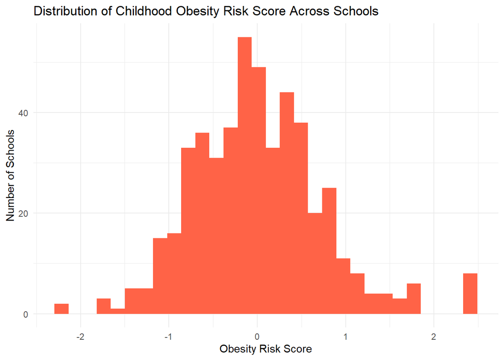

```r
ggplot(risk_data, aes(x = obesity_risk_score)) +
  geom_histogram(fill = "tomato", bins = 30) +
  labs(title = "Distribution of Childhood Obesity Risk Score Across Schools",
       x = "Obesity Risk Score",
       y = "Number of Schools") +
  theme_minimal()
```

```r
risk_data %>%
  arrange(desc(obesity_risk_score)) %>%
  select(school_name, zip, obesity_risk_score) %>%
  head(10)
```

```
                           school_name   zip obesity_risk_score
1        EDISON, THOMAS A. HIGH SCHOOL 19140           2.409041
2          FELTONVILLE ARTS & SCIENCES 19120           2.409041
3  PHILADELPHIA LEARNING ACADEMY-NORTH 19140           2.409041
4      CLEMENTE, ROBERTO MIDDLE SCHOOL 19140           2.409041
5                             THE LINC 19140           2.409041
6   COMMUNITY COUNCIL LEARNING ACADEMY 19140           2.409041
7                 ACHIEVE ACADEMY EAST 19140           2.409041
8            CROSSROADS @ HUNTING PARK 19140           2.409041
9         PAN AMERICAN ACADEMY CHARTER 19133           1.847216
10            CONSTITUTION HIGH SCHOOL 19106           1.815905
```

```r
summary(risk_data$obesity_risk_score)
```

```
       V1
 Min.   :-2.215739
 1st Qu.:-0.492531
 Median :-0.027483
 Mean   : 0.001648
 3rd Qu.: 0.464853
 Max.   : 2.409041
 NA's   :3
```

**Clustering of School Food Environments**

```r
library(dplyr)
library(ggplot2)

# Start from risk_data and add a row_id so we can track rows
risk_data2 <- risk_data %>%
  mutate(row_id = dplyr::row_number())

# Build clustering input with row_id, then drop NAs
cluster_input <- risk_data2 %>%
  select(
    row_id,
    healthy_ratio,
    area_unhealthy,
    pct_poverty,
    n_healthy_10
  ) %>%
  tidyr::drop_na()

# Scale only the numeric columns (not row_id)
cluster_mat <- cluster_input %>%
  select(-row_id) %>%
  scale()

# Run k-means on the complete cases
set.seed(123)
k3 <- kmeans(cluster_mat, centers = 3)

# Attach cluster labels back to the clustering dataframe
cluster_input$cluster <- k3$cluster

# Join cluster labels back to the full risk_data2 by row_id
risk_data2 <- risk_data2 %>%
  left_join(
    cluster_input %>%
      select(row_id, cluster),
    by = "row_id"
  )
```

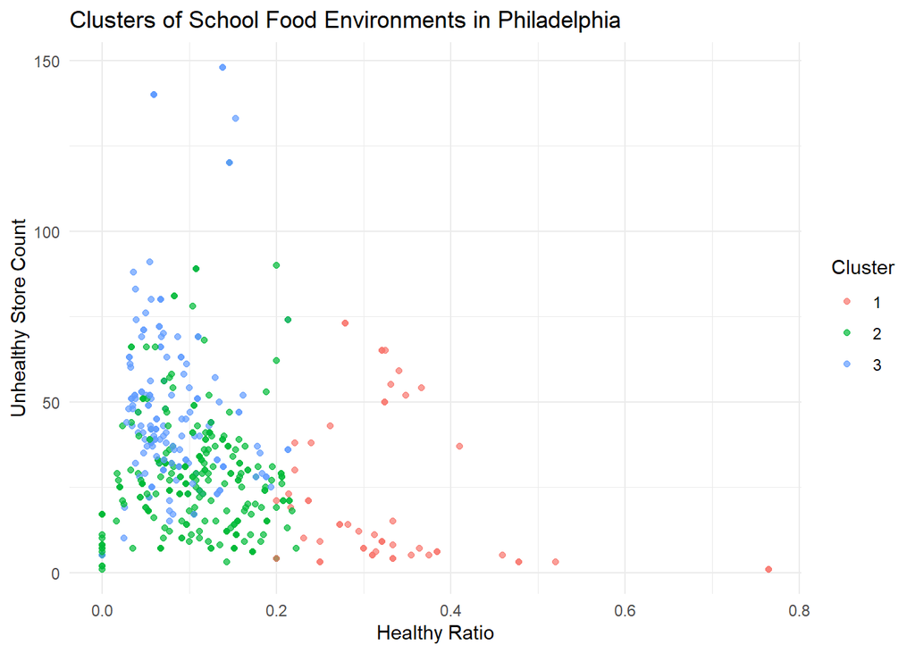

```r
ggplot(
  risk_data2 %>% filter(!is.na(cluster)),
  aes(x = healthy_ratio,
      y = area_unhealthy,
      color = factor(cluster))
) +
  geom_point(alpha = 0.7) +
  labs(
    title = "Clusters of School Food Environments in Philadelphia",
    x     = "Healthy Ratio",
    y     = "Unhealthy Store Count",
    color = "Cluster"
  ) +
  theme_minimal()
```

```r
risk_data2 %>%
  filter(!is.na(cluster)) %>%
  group_by(cluster) %>%
  summarize(
    mean_healthy_ratio = mean(healthy_ratio, na.rm = TRUE),
    mean_unhealthy     = mean(area_unhealthy, na.rm = TRUE),
    mean_poverty       = mean(pct_poverty, na.rm = TRUE),
    mean_risk_score    = mean(obesity_risk_score, na.rm = TRUE),
    mean_n_healthy_10    = mean(n_healthy_10, na.rm = TRUE),
    n_schools          = dplyr::n()
  )
```

```
# A tibble: 3 × 7
  cluster mean_healthy_ratio mean_unhealthy mean_poverty mean_risk_score
    <int>              <dbl>          <dbl>        <dbl>           <dbl>
1       1             0.329            21.8         12.2          -0.964
2       2             0.106            28.0         18.6          -0.272
3       3             0.0831           51.7         47.3           0.728
# ℹ 2 more variables: mean_n_healthy_10 <dbl>, n_schools <int>
```

Cluster 1 = low risk environments (best food areas)  
Cluster 1 schools had the highest healthy food ration (mean 0.33) and the lowest density of unhealthy retailers (mean 21.8) as well as the lowest mean poverty (mean 12%). This represents the most nutritious and resource-rich school environments.

Cluster 2 = moderate risk environments  
Cluster 2 showed moderately low healthy food availability (mean = 0.11) and elevated unhealthy food density (mean = 28.0) with moderate poverty levels (mean = 19%), indicating transitional neighborhoods with mixed food access.

Cluster 3 = high risk environments (worse food areas)  
Cluster 3 contained the most disadvantaged school environments, with the lowest healthy food ratio (mean = 0.08), the highest number of unhealthy retailers (mean = 51.7), and the highest poverty rates (mean = 47%).  
These areas represent neighborhoods with substantially elevated childhood obesity risk due to concentrated structural disadvantages and limited healthy food access.

These clusters align geographically with known disparities. Cluster 3 schools are assumed to be concentrated farther from Center City which are areas with higher chronic disease burden and lower life expectancy.

**Top Healthiest and Unhealthiest Schools**

```r
# Remove duplicate rows: keep one row per school
school_access_unique <- merged_data %>%
  distinct(school_id, .keep_all = TRUE)

# Top 10 healthiest schools
top_healthy <- school_access_unique %>%
  arrange(desc(healthy_ratio)) %>%
  select(school_name, healthy_ratio, area_healthy, area_unhealthy) %>%
  head(10)

top_healthy
```

```
                     school_name healthy_ratio area_healthy area_unhealthy
1       HENRY, CHARLES W. SCHOOL     0.5200000         3.25              3
2  JENKS ACADEMY ARTS & SCIENCES     0.4594595         4.25              5
3    MEREDITH, WILLIAM M. SCHOOL     0.4103586        25.75             37
4      MCCLOSKEY, JOHN F. SCHOOL     0.3750000         3.00              5
5   CHRISTOPHER COLUMBUS CHARTER     0.3665689        31.25             54
6    SAUL, WALTER B. HIGH SCHOOL     0.3636364         4.00              7
7     NEBINGER, GEORGE W. SCHOOL     0.3479624        27.75             52
8   CREATIVE AND PERFORMING ARTS     0.3407821        30.50             59
9           LANKENAU HIGH SCHOOL     0.3333333         2.00              4
10               SHAWMONT SCHOOL     0.3333333         4.00              8
```

```r
# Top 10 unhealthiest schools
top_unhealthy <- school_access_unique %>%
  arrange(healthy_ratio) %>%
  select(school_name, healthy_ratio, area_healthy, area_unhealthy) %>%
  head(10)

top_unhealthy
```

```
                     school_name healthy_ratio area_healthy area_unhealthy
1              BRIDESBURG SCHOOL             0            0              7
2        BROWN, JOSEPH H. SCHOOL             0            0              8
3           COMLY, WATSON SCHOOL             0            0              5
4  FRANKLIN TOWNE CHARTER SCHOOL             0            0             17
5      FRANKLIN TOWNE ELEMENTARY             0            0              7
6         PENNYPACK HOUSE SCHOOL             0            0              5
7       GREENBERG, JOSEPH SCHOOL             0            0              6
8        LAWTON, HENRY W. SCHOOL             0            0             17
9               FOX CHASE SCHOOL             0            0             10
10 TACONY ACADEMY CHARTER SCHOOL             0            0             11
```

I was curious about what the “healthiest” and “unhealthiest” schools in Philadelphia were.

healthy_ratio = proportion of nearby food outlets that are healthy  
area_healthy = estimated number of healthy stores in the surrounding area  
area_unhealthy = estimated number of unhealthy stores in the area

**Regression Models**

*Simple & Multiple Regression*

```r
library(dplyr)
library(ggplot2)

# Simple Regression Data
reg_data <- merged_data %>%
  distinct(school_id, .keep_all = TRUE) %>%
  filter(
    !is.na(healthy_ratio),
    !is.na(pct_poverty)
  )

# Simple Linear Regression
model_simple <- lm(healthy_ratio ~ pct_poverty, data = reg_data)
summary(model_simple)
```

```
Call:
lm(formula = healthy_ratio ~ pct_poverty, data = reg_data)

Residuals:
     Min       1Q   Median       3Q      Max
-0.15452 -0.04992 -0.01135  0.02964  0.37285

Coefficients:
              Estimate Std. Error t value Pr(>|t|)
(Intercept)  0.1578330  0.0081453  19.377  < 2e-16 ***
pct_poverty -0.0014682  0.0002255  -6.511 2.92e-10 ***
---
Signif. codes:  0 '***' 0.001 '**' 0.01 '*' 0.05 '.' 0.1 ' ' 1

Residual standard error: 0.08005 on 317 degrees of freedom
Multiple R-squared:  0.118, Adjusted R-squared:  0.1152
F-statistic:  42.4 on 1 and 317 DF,  p-value: 2.919e-10
```

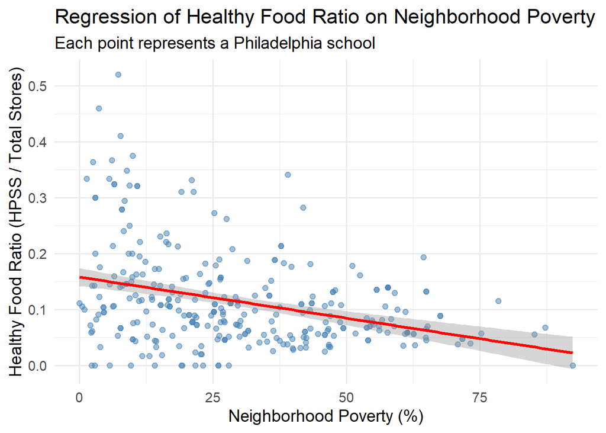

```r
# Simple Regression Plot
ggplot(reg_data, aes(x = pct_poverty, y = healthy_ratio)) +
  geom_point(alpha = 0.5, color = "steelblue") +
  geom_smooth(method = "lm", se = TRUE, color = "red", size = 1.2) +
  labs(
    title = "Regression of Healthy Food Ratio on Neighborhood Poverty",
    subtitle = "Each point represents a Philadelphia school",
    x = "Neighborhood Poverty (%)",
    y = "Healthy Food Ratio (HPSS / Total Stores)"
  ) +
  theme_minimal(base_size = 14)
```

```r
# Multiple Regression Data
reg_data_multi <- merged_data %>%
  distinct(school_id, .keep_all = TRUE) %>%
  filter(
    !is.na(healthy_ratio),
    !is.na(pct_poverty),
    !is.na(area_unhealthy),
    !is.na(pct_vehicle_avail)
  )

# Multiple Linear Regression
model_multi <- lm(
  healthy_ratio ~ pct_poverty + area_unhealthy + pct_vehicle_avail,
  data = reg_data_multi
)
summary(model_multi)
```

```
Call:
lm(formula = healthy_ratio ~ pct_poverty + area_unhealthy + pct_vehicle_avail,
    data = reg_data_multi)

Residuals:
     Min       1Q   Median       3Q      Max
-0.15697 -0.05045 -0.01074  0.02576  0.36854

Coefficients:
                    Estimate Std. Error t value Pr(>|t|)
(Intercept)        1.671e-01  2.403e-02   6.956 2.05e-11 ***
pct_poverty       -1.379e-03  2.740e-04  -5.033 8.14e-07 ***
area_unhealthy    -2.150e-04  1.903e-04  -1.130    0.259
pct_vehicle_avail -5.751e-05  2.674e-04  -0.215    0.830
---
Signif. codes:  0 '***' 0.001 '**' 0.01 '*' 0.05 '.' 0.1 ' ' 1

Residual standard error: 0.08026 on 314 degrees of freedom
Multiple R-squared:  0.1168,    Adjusted R-squared:  0.1084
F-statistic: 13.84 on 3 and 314 DF,  p-value: 1.682e-08
```

## 6 Limitations

The project is limited by the absence of Philadelphia specific childhood obesity data, the constrains of available spatial health outcomes, and the fact that food environment data sets measure geographic availability rather true affordability, accessibility, or quality.

Healthy food sources may be undercounted because healthy food environments relied on farmers markets, WIC locations, and high produce supply stores (HPSS). Farmers markets operate seasonally, WIC locations serve as more administrative rather than retail roles, and HPSS classifications may not capture the full range of healthy food access (eg. food cop-ops, specialty markets).

The food environment datasets indicate the presence of food outlets, but do not represent price differences, quality of available produce, store hours of reliability, and cultural relevance of food options. With this, the true accessibility of healthy foods may differ from what spatial data suggests.

## 7 Conclusion

This project examined the food environments surrounding Philadelphia schools and identified substantial spatial inequities in access to healthy vs unhealthy food sources. By integrating multiple data sets like neighborhood food retail, farmers markets, WIC offices, school locations, poverty indicators, walk ability measures, and national trends in childhood obesity, the analysis demonstrated the majority of Philadelphia schools are situated in environments that may increase children risk for obesity and poor nutrition.

Quantitative findings reveal disparities. Over 91% of schools are located in neighborhoods where healthy food retailers make up less than 25% of all food outlets. Schools in high poverty neighborhoods have a 40% lower healthy food ration (9.9% vs 15.7%) and 40% more unhealthy food retailers compared to schools in lower poverty neighborhoods. These patterns presume that students in disadvantaged areas are disproportionately surrounded by corner stores, fast food outlets, and other low produce stores, while having limited access to fresh fruits, vegetables, and nutritious options. Such environmental inequities mirror national trends showing rising childhood obesity and underscore how local food environments may reinforce broader health disparities.

Overall, we can conclude that children in schools farther from Center City may face risk for higher risks for childhood obesity, poverty, and lower life expectancy. This analysis demonstrated that Philadelphia’s school food environments are characterized by substantial inequities that align with known risk factors for childhood obesity. Improving access to healthy foods around schools through policy interventions, urban planning, community partnerships, or expansions of programs like WIC and farmers markets, represents a critical opportunity to support healthier environments for children and reduce preventable nutrition related disparities across the city.